# CMap Drug Safety Challenge: Gene test across samples of PHH, 10 µM and 24 h

Joaquim Aguirre-Plans

April 29, 2019

## Load files

First we load the R objects needed.

```r
load(drugs_file)
load(drug_info_file)
load(dilirank_file)
load(expression_file) # Requires cmapR
```

We load the gene information file as well, containing the landmark genes [More info](https://clue.io/connectopedia/l1000_gene_space).

```r
gene_info_df <- read.csv(gene_info_file, header=TRUE, sep="\t")
landmark_genes <- gene_info_df$pr_gene_id[gene_info_df$pr_is_lm==1]
```

I subset the DILIConcern data by those drugs that have the same label in the columns DILIConcern and vDILIConcern.

```r
drank.sel$DILIConcern[drank.sel$DILIConcern == "No-DILI-concern"] <- "No-DILI-Concern" # Correct the 4 entries with lowercase concern
# We remove the first letter from vDILIConcern entries (except Ambiguous)
drank.sel$vDILIConcern[drank.sel$vDILIConcern != "Ambiguous DILI-concern"] <- sub('.', '', drank.sel$vDILIConcern[drank.sel$vDILIConcern != "Ambiguous DILI-concern"])
# We subset the table by those drugs that have the same value in vDILIConcern and DILIConcern columns
dilirank_df <- drank.sel[drank.sel$vDILIConcern == drank.sel$DILIConcern,]
most_concern_drugs <- dilirank_df$pert_iname[dilirank_df$DILIConcern == "Most-DILI-Concern"]
less_concern_drugs <- dilirank_df$pert_iname[dilirank_df$DILIConcern == "Less-DILI-Concern"]
most_less_concern_drugs <- union(most_concern_drugs, less_concern_drugs)
no_concern_drugs <- dilirank_df$pert_iname[dilirank_df$DILIConcern == "No-DILI-Concern"]
```

We have 175 compounds:

- Most-DILI-Concern: 37
- Less-DILI-Concern: 87
- No-DILI-Concern: 51

```r
# Subset the GCT object by Most-DILI-Concern drugs
id_most <- which(gct@cdesc$pert_iname %in% most_less_concern_drugs)
gct_most <- subset.gct(gct, cid=id_most)
# Subset the GCT object by No-DILI-Concern drugs
id_no <- which(gct@cdesc$pert_iname %in% no_concern_drugs)
gct_no <- subset.gct(gct, cid=id_no)
```

The best conditions to analyse the expression of drugs are 10 µM and 24 h. We will check the number of samples per type of drug that we have in each cell line:

```r
id_most_10_24 <- which(gct_most@cdesc$pert_idose == "10 µM" & gct_most@cdesc$pert_itime == "24 h")
gct_most_10_24 <- subset.gct(gct_most, cid=id_most_10_24)
table(gct_most_10_24@cdesc$cell_id)
```

```
##
##     A375     A549      ASC     BT20  FIBRNPC     HA1E   HCC515  HEK293T
##       22      235      152        5       28      154      142        2
##    HEPG2   HS578T     HT29   MCF10A     MCF7 MDAMB231      NEU    NKDBA
##        7        5       19        5      400        5       54        9
##      NPC      PC3      PHH      SKB    SKBR3     VCAP
##      178      368      147      152        5      295
```

```r
id_no_10_24 <- which(gct_no@cdesc$pert_idose == "10 µM" & gct_no@cdesc$pert_itime == "24 h")
gct_no_10_24 <- subset.gct(gct_no, cid=id_no_10_24)
table(gct_no_10_24@cdesc$cell_id)
```

```
##
##    A375    A549     ASC FIBRNPC    HA1E  HCC515 HEK293T   HEPG2    HT29
##      42     134      70      14      85      70       1       7      38
##    MCF7     NEU   NKDBA     NPC     PC3     PHH     SKB    VCAP
##     207      31       6      83     189      64      70     149
```

Among these cell lines, there are three liver cell lines according to the cell info file:

```r
cell_info_df <- read.csv(cell_info_file, header=TRUE, sep="\t")
cell_info_df[cell_info_df$primary_site == "liver",]
```

```
##    cell_id cell_type base_cell_id precursor_cell_id modification
## 25   HEPG2 cell line        HEPG2              -666         -666
## 33    HUH7 cell line         HUH7              -666         -666
## 95     PHH   primary          PHH              -666         -666
##    sample_type primary_site                  subtype
## 25       tumor        liver hepatocellular carcinoma
## 33       tumor        liver hepatocellular carcinoma
## 95     primary        liver     normal primary liver
##    original_growth_pattern provider_catalog_id original_source_vendor
## 25                adherent             HB-8065                   ATCC
## 33                adherent                -666                  HSRRB
## 95                    -666                -666            CellzDirect
##    donor_age donor_sex donor_ethnicity
## 25        15         M       Caucasian
## 33      -666         M            -666
## 95      -666      -666            -666
```

```r
id_most_phh_10_24 <- which(gct_most_10_24@cdesc$cell_id == "PHH")
gct_most_phh_10_24 <- subset.gct(gct_most_10_24, cid=id_most_phh_10_24)
id_no_phh_10_24 <- which(gct_no_10_24@cdesc$cell_id == "PHH")
gct_no_phh_10_24 <- subset.gct(gct_no_10_24, cid=id_no_phh_10_24)
```

## Compare the expression of each gene across samples of Most-DILI-Concern vs. No-DILI-Concern in PHH cell line, 10 µM and 24 h

For each gene, we will check the difference of expression between Most-DILI-Concern drugs and No-DILI-Concern drugs using a Wilcoxon rank-sum test (or Mann-Whitney U test) ([More info](https://stat.ethz.ch/R-manual/R-devel/library/stats/html/wilcox.test.html)).

```r
# Create new dataframe to store the results
cols <- c("gene_id", "landmark", "statistic", "p.value")
wilcox_df <- data.frame(matrix(ncol = length(cols), nrow=0))
colnames(wilcox_df) <- cols

# Calculate the wilcoxon for each gene and store the results
#output_table <- "/home/quim/PHD/Projects/camda/results/gene_test_phh_10_24.tsv"
output_table <- "/home/quim/PHD/Projects/camda/results/gene_test_landmark_phh_10_24_mixlessmost.tsv"
if(!file.exists(output_table)){
  #for (gene_id in gct_most_phh_10_24@rid) {
  for (gene_id in landmark_genes) {
    most_expr <- gct_most_phh_10_24@mat[gct_most_phh_10_24@rid == gene_id]
    no_expr <- gct_no_phh_10_24@mat[gct_no_phh_10_24@rid == gene_id]
    res <- wilcox.test(most_expr, no_expr, alternative = "two.sided", paired = FALSE)
    landmark <- gene_id %in% landmark_genes
    wilcox_df[nrow(wilcox_df)+1,] <- c(gene_id, landmark, res$statistic, res$p.value)
  }
  wilcox_df$p.value <- as.numeric(wilcox_df$p.value)
  wilcox_df$p.adjust <- p.adjust(wilcox_df$p.value, "BH")
  write.table(wilcox_df, file = output_table,row.names=FALSE, na="-",col.names=TRUE, sep="\t")
}else{
  wilcox_df = read.csv(output_table, header = TRUE, sep = "\t")
}
head(wilcox_df)
```

```
##   gene_id landmark statistic     p.value  p.adjust
## 1     780        1    4907.0 0.619396665 0.9684878
## 2    7849        1    5143.0 0.282113965 0.9074508
## 3    6193        1    4741.5 0.927686381 0.9873152
## 4      23        1    5066.0 0.375234247 0.9161004
## 5    9552        1    5779.0 0.008398723 0.5422462
## 6     387        1    4296.0 0.317531531 0.9122890
```

Among the 978 genes, there are 0 genes with an adjusted p-value under 0.05 and 0 under 0.01.

We will make a heatmap to plot the expression of the genes for each drug.

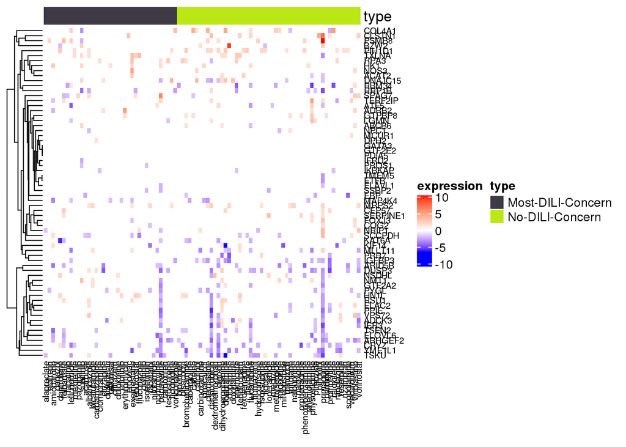

```r
# Define the genes found
all_wilcox_gene_ids <- unique(wilcox_df$gene_id[wilcox_df$p.value<0.01])
all_wilcox_gene_ids_05 <- unique(wilcox_df$gene_id[wilcox_df$p.value<0.05])
landmark_wilcox_gene_ids <- unique(wilcox_df$gene_id[wilcox_df$p.value<0.01 & wilcox_df$landmark==TRUE])
landmark_wilcox_gene_ids_05 <- unique(wilcox_df$gene_id[wilcox_df$p.value<0.05 & wilcox_df$landmark==TRUE])

# Get a vector of gene symbols ordered equal to the vector of gene IDs
genes_selected <- landmark_wilcox_gene_ids_05
genes_df <- data.frame(1:length(genes_selected), genes_selected)
colnames(genes_df)<- c("id", "pr_gene_id")
genes_df <- merge(genes_df, gene_info_df[,c("pr_gene_id", "pr_gene_symbol")], by="pr_gene_id")
genes_df <- genes_df[order(genes_df$id), ]
genes_df$id <- NULL

# Create new dataframe to store the matrix
cols <- c(most_concern_drugs, no_concern_drugs)
rows <- genes_df$pr_gene_symbol
heat_df <- data.frame(matrix(ncol = length(cols), nrow=length(rows)))
colnames(heat_df) <- cols
rownames(heat_df) <- rows
gene_ids <- genes_df$pr_gene_id

# Introduce the data in the matrix
for (drug in most_concern_drugs){
  id_drug <- which(gct_most_phh_10_24@cdesc$pert_iname == drug)
  id_genes <- which(gct_most_phh_10_24@rid %in% gene_ids)
  gct_drug <- subset.gct(gct_most_phh_10_24, cid=id_drug, rid=id_genes)
  #means<- rowMeans(gct_drug@mat)
  medians <- apply(gct_drug@mat, 1, median)
  heat_df[drug] <- medians
}
for (drug in no_concern_drugs){
  id_drug <- which(gct_no_phh_10_24@cdesc$pert_iname == drug)
  id_genes <- which(gct_no_phh_10_24@rid %in% gene_ids)
  gct_drug <- subset.gct(gct_no_phh_10_24, cid=id_drug, rid=id_genes)
  #means<- rowMeans(gct_drug@mat)
  medians <- apply(gct_drug@mat, 1, median)
  heat_df[drug] <- medians
}
# Save the table
output_table <- "/home/quim/PHD/Projects/camda/results/gene_test_heatmap_data_phh_10_24_mixlessmost.tsv"
write.table(heat_df, file = output_table,row.names=TRUE, na="-",col.names=TRUE, sep="\t")

# Draw the heatmap
#heatmap(as.matrix(heat_df), Colv = NA, Rowv = NA, scale="column")
#heatmap.2(as.matrix(heat_df), col=bluered, Colv = NA, Rowv = NA, scale="row", trace="none")
#heatmap.2(as.matrix(heat_df), col=bluered, Colv = NA, Rowv = NA, scale="none", trace="none") #no scale means we use the raw z-scores
#cc <- c(rep("green", times=length(most_concern_drugs)), rep("yellow", times=length(no_concern_drugs)))
#cc2 <- c(rep("#004f00", times=length(most_concern_drugs)), rep("#9a9a00", times=length(no_concern_drugs)))
#heatmap.2(as.matrix(heat_df), col=bluered, Colv = NA, Rowv = NA, scale="none", trace="none", ColSideColors=cc, colCol=cc2) #no scale means we use the raw z-scores

type <- c(rep("Most-DILI-Concern", times=length(most_concern_drugs)), rep("No-DILI-Concern", times=length(no_concern_drugs)))
annotation <- HeatmapAnnotation(df = data.frame(type = type))
#Heatmap(heat_df, name = "expression", km = 0, col = colorRamp2(c(min(heat_df), 0, max(heat_df)), c("blue", "white", "red")), top_annotation = annotation, cluster_rows=FALSE, cluster_columns=FALSE)

# New heatmap using ComplexHeatmap
heat_df_for_plot <- heat_df
heat_df_for_plot <- apply(heat_df_for_plot, c(1,2),  function(x) {ifelse(abs(x)>1.5, x, 0)})

Cairo::CairoPDF("paths_all.pdf", width = 10, height = 10) # Save in PDF
Heatmap(heat_df_for_plot, name = "expression", km = 0, col = colorRamp2(c(min(heat_df), 0, max(heat_df)), c("blue", "white", "red")), top_annotation = annotation, cluster_rows=TRUE, cluster_columns=FALSE,  row_names_gp = gpar(fontsize = 7)  ,column_names_gp =  gpar(fontsize = 7)  )
```

```r
dev.off()
```

## Perform the same analysis removing the outliers daunorubicin and vorinostat

```r
# Remove daunorubicin and vorinostat from no_concern_drugs
outliers = c('daunorubicin', 'vorinostat')
no_concern_drugs_noout <- no_concern_drugs[!no_concern_drugs %in% outliers]
id_no_phh_10_24_noout <- which(!gct_no_phh_10_24@cdesc$pert_iname %in% outliers)
gct_no_phh_10_24_noout <- subset.gct(gct_no_phh_10_24, cid=id_no_phh_10_24_noout)

# Create new dataframe to store the results
cols <- c("gene_id", "landmark", "statistic", "p.value")
wilcox_noout_df <- data.frame(matrix(ncol = length(cols), nrow=0))
colnames(wilcox_noout_df) <- cols

# Calculate the wilcoxon for each gene and store the results
#output_table <- "/home/quim/PHD/Projects/camda/results/gene_test_phh_10_24_noout.tsv"
output_table <- "/home/quim/PHD/Projects/camda/results/gene_test_landmark_phh_10_24_noout_mixlessmost.tsv"
if(!file.exists(output_table)){
  #for (gene_id in gct_most_phh_10_24@rid) {
  for (gene_id in landmark_genes) {
    most_expr <- gct_most_phh_10_24@mat[gct_most_phh_10_24@rid == gene_id]
    no_expr <- gct_no_phh_10_24_noout@mat[gct_no_phh_10_24_noout@rid == gene_id]
    res <- wilcox.test(most_expr, no_expr, alternative = "two.sided", paired = FALSE)
    landmark <- gene_id %in% landmark_genes
    wilcox_noout_df[nrow(wilcox_noout_df)+1,] <- c(gene_id, landmark, res$statistic, res$p.value)
  }
  wilcox_noout_df$p.value <- as.numeric(wilcox_noout_df$p.value)
  wilcox_noout_df$p.adjust <- p.adjust(wilcox_noout_df$p.value, "BH")
  write.table(wilcox_noout_df, file = output_table,row.names=FALSE, na="-",col.names=TRUE, sep="\t")
}else{
  wilcox_noout_df = read.csv(output_table, header = TRUE, sep = "\t")
}
head(wilcox_noout_df)
```

```
##   gene_id landmark statistic   p.value p.adjust
## 1     780        1    4307.0 0.6105878 0.999956
## 2    7849        1    4155.0 0.9180295 0.999956
## 3    6193        1    4345.5 0.5404379 0.999956
## 4      23        1    4394.0 0.4582095 0.999956
## 5    9552        1    4945.0 0.0267805 0.999956
## 6     387        1    3980.0 0.7171940 0.999956
```

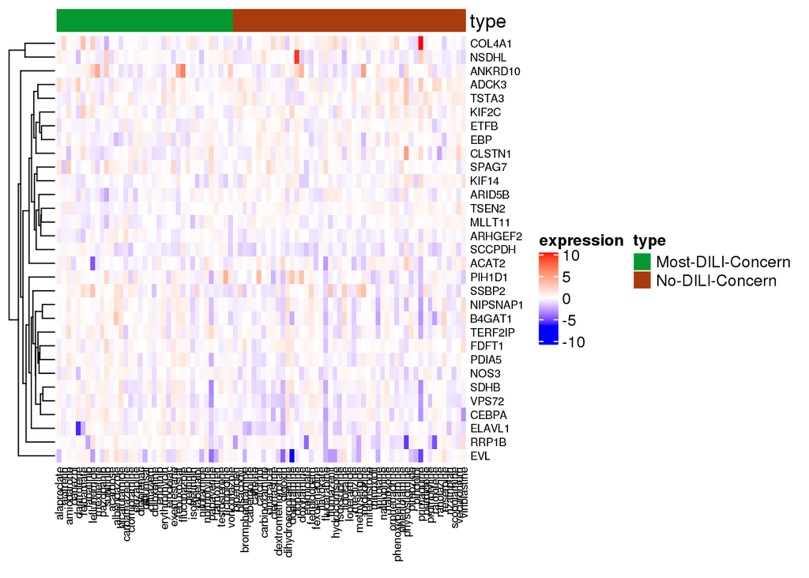

```r
# Define the genes found
all_wilcox_gene_ids_noout <- unique(wilcox_noout_df$gene_id[wilcox_noout_df$p.value<0.01])
all_wilcox_gene_ids_noout_05 <- unique(wilcox_noout_df$gene_id[wilcox_noout_df$p.value<0.05])
landmark_wilcox_gene_ids_noout <- unique(wilcox_noout_df$gene_id[wilcox_noout_df$p.value<0.01 & wilcox_noout_df$landmark==TRUE])
landmark_wilcox_gene_ids_noout_05 <- unique(wilcox_noout_df$gene_id[wilcox_noout_df$p.value<0.05 & wilcox_noout_df$landmark==TRUE])

# Get a vector of gene symbols ordered equal to the vector of gene IDs
genes_selected_noout <- landmark_wilcox_gene_ids_noout_05
genes_noout_df <- data.frame(1:length(genes_selected_noout), genes_selected_noout)
colnames(genes_noout_df)<- c("id", "pr_gene_id")
genes_noout_df <- merge(genes_noout_df, gene_info_df[,c("pr_gene_id", "pr_gene_symbol")], by="pr_gene_id")
genes_noout_df <- genes_noout_df[order(genes_noout_df$id), ]
genes_noout_df$id <- NULL

# Create new dataframe to store the matrix
cols <- c(most_concern_drugs, no_concern_drugs_noout)
rows <- genes_noout_df$pr_gene_symbol
heat_noout_df <- data.frame(matrix(ncol = length(cols), nrow=length(rows)))
colnames(heat_noout_df) <- cols
rownames(heat_noout_df) <- rows
gene_ids <- genes_noout_df$pr_gene_id

# Introduce the data in the matrix
for (drug in most_concern_drugs){
  id_drug <- which(gct_most_phh_10_24@cdesc$pert_iname == drug)
  id_genes <- which(gct_most_phh_10_24@rid %in% gene_ids)
  gct_drug <- subset.gct(gct_most_phh_10_24, cid=id_drug, rid=id_genes)
  #means<- rowMeans(gct_drug@mat)
  medians <- apply(gct_drug@mat, 1, median)
  heat_noout_df[drug] <- medians
}
for (drug in no_concern_drugs_noout){
  id_drug <- which(gct_no_phh_10_24_noout@cdesc$pert_iname == drug)
  id_genes <- which(gct_no_phh_10_24_noout@rid %in% gene_ids)
  gct_drug <- subset.gct(gct_no_phh_10_24_noout, cid=id_drug, rid=id_genes)
  #means<- rowMeans(gct_drug@mat)
  medians <- apply(gct_drug@mat, 1, median)
  heat_noout_df[drug] <- medians
}
# Save the table
output_table <- "/home/quim/PHD/Projects/camda/results/gene_test_heatmap_data_phh_10_24_noout.tsv"
write.table(heat_noout_df, file = output_table,row.names=TRUE, na="-",col.names=TRUE, sep="\t")

# ComplexHeatmap
type <- c(rep("Most-DILI-Concern", times=length(most_concern_drugs)), rep("No-DILI-Concern", times=length(no_concern_drugs_noout)))
annotation <- HeatmapAnnotation(df = data.frame(type = type))
Cairo::CairoPDF("/home/quim/PHD/Projects/camda/results/heatmap_phh_10_24_landmark_noout_mixlessmost.pdf", width = 10, height = 10) # Save in PDF
Heatmap(heat_noout_df, name = "expression", km = 0, col = colorRamp2(c(min(heat_noout_df), 0, max(heat_noout_df)), c("blue", "white", "red")), top_annotation = annotation, cluster_rows=TRUE, cluster_columns=FALSE,  row_names_gp = gpar(fontsize = 7)  ,column_names_gp =  gpar(fontsize = 7))
```

```r
dev.off()
```

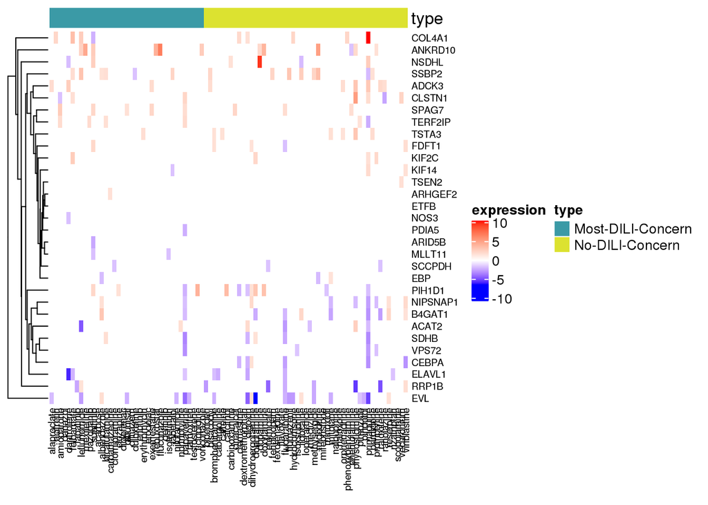

```r
# ComplexHeatmap removing expression lower than abs(1.5)
heat_df_for_plot <- heat_noout_df
heat_df_for_plot <- apply(heat_df_for_plot, c(1,2),  function(x) {ifelse(abs(x)>1.5, x, 0)})
type <- c(rep("Most-DILI-Concern", times=length(most_concern_drugs)), rep("No-DILI-Concern", times=length(no_concern_drugs_noout)))
annotation <- HeatmapAnnotation(df = data.frame(type = type))
Cairo::CairoPDF("/home/quim/PHD/Projects/camda/results/heatmap_phh_mixlessmost_10_24_landmark_noout_above1_5_mixlessmost.pdf", width = 10, height = 10) # Save in PDF
#Cairo::CairoPNG("/home/quim/PHD/Projects/camda/results/heatmap_phh_mixlessmost_10_24_landmark_noout_above1_5_mixlessmost.png", width = 500, height = 500) # Save in PNG
Heatmap(heat_df_for_plot, name = "expression", km = 0, col = colorRamp2(c(min(heat_noout_df), 0, max(heat_noout_df)), c("blue", "white", "red")), top_annotation = annotation, cluster_rows=TRUE, cluster_columns=FALSE,  row_names_gp = gpar(fontsize = 7)  ,column_names_gp =  gpar(fontsize = 7)  )
```

```r
dev.off()
```